# Case Study 1 DDS 6306

Cameron Stewart and Adam Alidra

3/5/2021

## Introduction

#### Craft Beer and Brewery Report for CEO and CFO of Budweiser:

#### In this report, you will find our team’s analysis and response to the seven questions requested from Budweiser and our team’s additional insights based on the Beers and Breweries datasets. The initial investigation is a state level study of Brewery count, median ABV, and median IBU. Looking deeper at the key beer characteristics, our team examined the distribution of ABV, the relationship between ABV vs. IBU, and noted extreme values.

#### Utilizing the relationship between ABV and IBU, our team deployed machine learning techniques (KNN and Naive Bayes) to predict the beer style. The first model predicts IPA vs. Other Ales and the second model classifies each beer to a generalized list of beer styles. For each analysis, NA’s will be addressed when applicable.

## Load the required libraries, read in the data, and adjust variables to the correct type

```r
library(naniar)
library(stringr)
library(class)
library(caret)
library(e1071)
library(plyr)
library(dplyr)
library(ggthemes)
library(tidyverse)
##Read in beers.csv and convert variables to the appropriate class. Also change the 'Name' column to be more specific due to conflict in the other dataset
# Beers.csv Variables:
#
#   Name: Name of the beer.
#
#   Beer_ID: Unique identifier of the beer.
#
#   ABV: Alcohol by volume of the beer.
#
#   IBU: International Bitterness Units of the beer.
#
#   Brewery_ID: Brewery id associated with the beer.
#
#   Style: Style of the beer.
#
#   Ounces: Ounces of beer.

beers = read.csv('/Users/adalidra/Desktop/Data Science Program/DS6306/MSDS_6306_Doing-Data-Science/Unit 8 and 9 Case Study 1/Beers.csv',header = TRUE)

colnames(beers)[1]="Beer_Name"
beers$Beer_ID = as.factor(beers$Beer_ID)
beers$Brewery_id = as.factor(beers$Brewery_id)
beers$Style = as.factor(beers$Style)
str(beers)
```

```
## 'data.frame':    2410 obs. of  7 variables:
##  $ Beer_Name : chr  "Pub Beer" "Devil's Cup" "Rise of the Phoenix" "Sinister" ...
##  $ Beer_ID   : Factor w/ 2410 levels "1","4","5","6",..: 1188 1988 1987 1986 1985 1984 1983 1982 1981 1860 ...
##  $ ABV       : num  0.05 0.066 0.071 0.09 0.075 0.077 0.045 0.065 0.055 0.086 ...
##  $ IBU       : int  NA NA NA NA NA NA NA NA NA NA ...
##  $ Brewery_id: Factor w/ 558 levels "1","2","3","4",..: 409 178 178 178 178 178 178 178 178 178 ...
##  $ Style     : Factor w/ 100 levels "","Abbey Single Ale",..: 19 18 16 12 16 80 18 22 18 12 ...
##  $ Ounces    : num  12 12 12 12 12 12 12 12 12 12 ...
```

```r
##Read in breweries.csv and convert variables to the appropriate class. Also change the 'Name' column to be more specific due to conflict with the other dataset
# Breweries.csv Variables:
#
#   Brew_ID: Unique identifier of the brewery.
#
#   Name: Name of the brewery.
#
#   City: City where the brewery is located.
#
#   State: U.S. State where the brewery is located.

breweries = read.csv('/Users/adalidra/Desktop/Data Science Program/DS6306/MSDS_6306_Doing-Data-Science/Unit 8 and 9 Case Study 1/Breweries.csv',header = TRUE)
colnames(breweries)[2] = "Brewery_Name"
breweries$Brew_ID = as.factor(breweries$Brew_ID)
breweries$City = as.factor(breweries$City)
breweries$State = as.factor(breweries$State)
str(breweries)
```

```
## 'data.frame':    558 obs. of  4 variables:
##  $ Brew_ID     : Factor w/ 558 levels "1","2","3","4",..: 1 2 3 4 5 6 7 8 9 10 ...
##  $ Brewery_Name: chr  "NorthGate Brewing " "Against the Grain Brewery" "Jack's Abby Craft Lagers" "Mike Hess Brewing Company" ...
##  $ City        : Factor w/ 384 levels "Abingdon","Abita Springs",..: 228 200 122 299 300 62 91 48 152 136 ...
##  $ State       : Factor w/ 51 levels " AK"," AL"," AR",..: 24 18 20 5 5 41 6 23 23 23 ...
```

## Find the count of Breweries located in each state

```r
#Create breweries_by_state to store summarized data of Count of Breweries by State
breweries_by_state = data.frame(breweries %>% group_by(State) %>% summarise(Count = n()) %>% arrange(desc(Count)))
breweries_by_state
```

```
##    State Count
## 1     CO    47
## 2     CA    39
## 3     MI    32
## 4     OR    29
## 5     TX    28
## 6     PA    25
## 7     MA    23
## 8     WA    23
## 9     IN    22
## 10    WI    20
## 11    NC    19
## 12    IL    18
## 13    NY    16
## 14    VA    16
```

[output cut: 37 more lines]

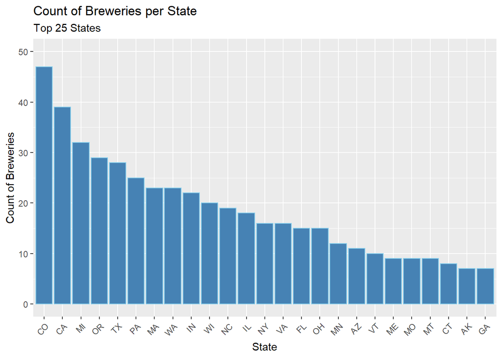

```r
##Display Count of Breweries by State

#For readability displaying first 25 and last 26 on the same y-scale

head(breweries_by_state,25) %>% ggplot(aes(x=reorder(State,-Count),y=Count))+geom_bar(stat = 'identity',color='skyblue',fill='steelblue') + xlab("State") + ylab("Count of Breweries") + ggtitle("Count of Breweries per State","Top 25 States") + theme(axis.text.x=element_text(angle=45, hjust=1)) + scale_y_continuous(breaks = seq(0,50,10),limits = c(0,50))
```

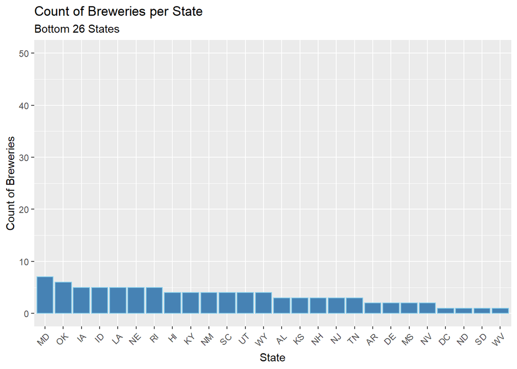

```r
tail(breweries_by_state,26) %>% ggplot(aes(x=reorder(State,-Count),y=Count))+geom_bar(stat = 'identity',color='skyblue',fill='steelblue') + xlab("State") + ylab("Count of Breweries") + ggtitle("Count of Breweries per State","Bottom 26 States") + theme(axis.text.x=element_text(angle=45, hjust=1)) + scale_y_continuous(breaks = seq(0,50,10),limits = c(0,50))
```

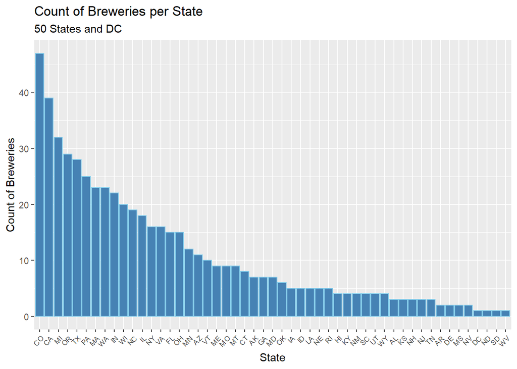

```r
#Full 51 states in one plot with small text
head(breweries_by_state, 51) %>% ggplot(aes(x=reorder(State,-Count),y=Count))+geom_bar(stat = 'identity',color='skyblue',fill='steelblue') + xlab("State") + ylab("Count of Breweries") + ggtitle("Count of Breweries per State", "50 States and DC") + theme(axis.text.x=element_text(size= 7, angle=45, hjust=1))
```

#### 558 Total Breweries listed in the Breweries data set. Top 25% of states contain over 60% of the Breweries. CO and CA have the most Breweries in total.

## Merge the beer data with the breweries data. Printing the first 6 observations and the last 6 observations to check the merged file.

```r
#Merge the two data sets into beers_merge on Brewery_id and Brew_ID
beers_merge=merge(beers,breweries,by.x = "Brewery_id", by.y = "Brew_ID")
str(beers_merge)
```

```
## 'data.frame':    2410 obs. of  10 variables:
##  $ Brewery_id  : Factor w/ 558 levels "1","2","3","4",..: 1 1 1 1 1 1 10 100 101 101 ...
##  $ Beer_Name   : chr  "Get Together" "Maggie's Leap" "Wall's End" "Pumpion" ...
##  $ Beer_ID     : Factor w/ 2410 levels "1","4","5","6",..: 2410 2409 2408 2407 2406 2405 2359 2161 2160 2078 ...
##  $ ABV         : num  0.045 0.049 0.048 0.06 0.06 0.056 0.052 0.089 0.09 0.07 ...
##  $ IBU         : int  50 26 19 38 25 47 NA 126 NA NA ...
##  $ Style       : Factor w/ 100 levels "","Abbey Single Ale",..: 16 77 48 83 22 57 18 12 66 22 ...
##  $ Ounces      : num  16 16 16 16 16 16 16 12 12 12 ...
##  $ Brewery_Name: chr  "NorthGate Brewing " "NorthGate Brewing " "NorthGate Brewing " "NorthGate Brewing " ...
##  $ City        : Factor w/ 384 levels "Abingdon","Abita Springs",..: 228 228 228 228 228 228 136 71 192 192 ...
##  $ State       : Factor w/ 51 levels " AK"," AL"," AR",..: 24 24 24 24 24 24 23 36 18 18 ...
```

```r
#Display first and last 6 values in merged data set
head(beers_merge,6)
```

```
##   Brewery_id     Beer_Name Beer_ID   ABV IBU
## 1          1  Get Together    2692 0.045  50
## 2          1 Maggie's Leap    2691 0.049  26
## 3          1    Wall's End    2690 0.048  19
## 4          1       Pumpion    2689 0.060  38
## 5          1    Stronghold    2688 0.060  25
## 6          1   Parapet ESB    2687 0.056  47
##                                 Style Ounces       Brewery_Name        City
## 1                        American IPA     16 NorthGate Brewing  Minneapolis
## 2                  Milk / Sweet Stout     16 NorthGate Brewing  Minneapolis
## 3                   English Brown Ale     16 NorthGate Brewing  Minneapolis
## 4                         Pumpkin Ale     16 NorthGate Brewing  Minneapolis
## 5                     American Porter     16 NorthGate Brewing  Minneapolis
## 6 Extra Special / Strong Bitter (ESB)     16 NorthGate Brewing  Minneapolis
##   State
## 1    MN
## 2    MN
## 3    MN
## 4    MN
## 5    MN
## 6    MN
```

```r
tail(beers_merge,6)
```

```
##      Brewery_id                      Beer_Name Beer_ID   ABV IBU
## 2405         98         Troegenator Doublebock    1510 0.082  25
## 2406         98                  Perpetual IPA    1509 0.075  85
## 2407         99                    Cortez Gold    2442 0.050  NA
## 2408         99                    Mission IPA    2441 0.068  66
## 2409         99 El Conquistador Extra Pale Ale    1460 0.048  44
## 2410         99         Shipwrecked Double IPA    1459 0.092  75
##                               Style Ounces            Brewery_Name      City
## 2405                     Doppelbock     16 TrÃ¶egs Brewing Company   Hershey
## 2406                   American IPA     12 TrÃ¶egs Brewing Company   Hershey
## 2407               Belgian Pale Ale     32         Mission Brewery San Diego
## 2408                   American IPA     32         Mission Brewery San Diego
## 2409        American Pale Ale (APA)     32         Mission Brewery San Diego
## 2410 American Double / Imperial IPA     32         Mission Brewery San Diego
##      State
## 2405    PA
## 2406    PA
## 2407    CA
## 2408    CA
## 2409    CA
## 2410    CA
```

## Address the NA values

```r
#Summarize NA for each variable in all three data frames. Then visualize the merged dataframe NAs
miss_var_cumsum(beers)
```

```
## # A tibble: 7 x 3
##   variable   n_miss n_miss_cumsum
##   <chr>       <int>         <int>
## 1 Beer_Name       0             0
## 2 Beer_ID         0             0
## 3 ABV            62            62
## 4 IBU          1005          1067
## 5 Brewery_id      0          1067
## 6 Style           0          1067
## 7 Ounces          0          1067
```

```r
miss_var_cumsum(breweries)
```

```
## # A tibble: 4 x 3
##   variable     n_miss n_miss_cumsum
##   <chr>         <int>         <int>
## 1 Brew_ID           0             0
## 2 Brewery_Name      0             0
## 3 City              0             0
## 4 State             0             0
```

```r
miss_var_cumsum(beers_merge)
```

```
## # A tibble: 10 x 3
##    variable     n_miss n_miss_cumsum
##    <chr>         <int>         <int>
##  1 Brewery_id        0             0
##  2 Beer_Name         0             0
##  3 Beer_ID           0             0
##  4 ABV              62            62
##  5 IBU            1005          1067
##  6 Style             0          1067
##  7 Ounces            0          1067
##  8 Brewery_Name      0          1067
##  9 City              0          1067
## 10 State             0          1067
```

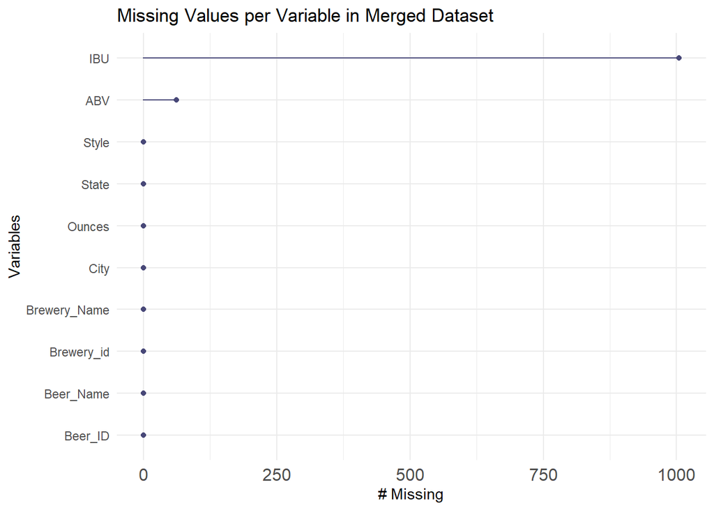

```r
gg_miss_var(beers_merge) + ggtitle("Missing Values per Variable in Merged Dataset") + theme(axis.text.x=element_text(size= 12))
```

```r
sum(!complete.cases(beers_merge))
```

```
## [1] 1005
```

#### The breweries data frame has no NA values but the beers data frame has 1067 NA values. When the two tables are merged together, the 1067 NA values from the beers data frame are transferred to the beers_merge data frame. There are 1005 NA values in IBU and 62 NA values in ABV. There are 1005 rows with at least one NA. When we are analyzing a single column (e.g. ABV), we will use all non-NA values in that column. When we analyze multiple variables simultaneously (e.g. ABV and IBU), we will only use rows with no NAs in any of the variables of interest.

## Compute the median ABV and IBU for each state. Plot a bar chart to compare

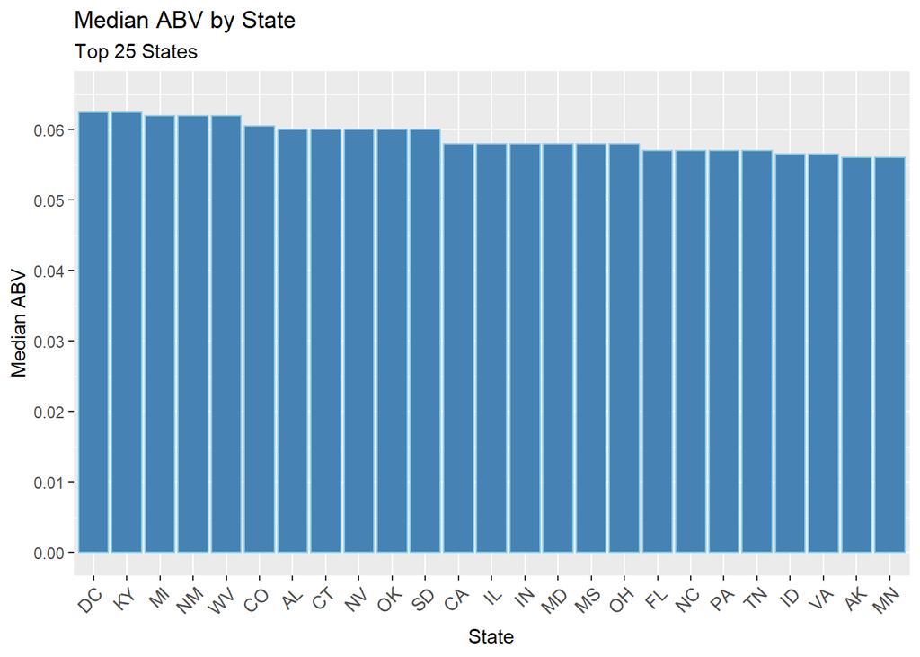

```r
#Create summarized data in ABV_IBU_by_state frame with ABV and IBU medians by state
ABV_IBU_by_state = data.frame(beers_merge %>% group_by(State) %>% summarise(median_ABV = median(ABV,na.rm = TRUE), median_IBU = median(IBU,na.rm = TRUE)))

##Plot Median ABV by State

#Re-order the factors for median_ABV so the bar chart can be plotted in descending order
ABV_IBU_by_state$State= fct_reorder(ABV_IBU_by_state$State, desc(ABV_IBU_by_state$median_ABV))

#Arrange the data frame where median_ABV is in descending order so that the data frame can be sliced
ABV_IBU_by_state = ABV_IBU_by_state %>% arrange(desc(median_ABV))

#For readability displaying first 25 and last 26 on the same y-scale
head(ABV_IBU_by_state,25) %>% ggplot(aes(x=State,y=median_ABV)) + geom_bar(stat = 'identity',color='skyblue',fill='steelblue') + xlab("State") + ylab("Median ABV") + ggtitle("Median ABV by State","Top 25 States") + theme(axis.text.x=element_text(size= 10, angle=45, hjust=1)) + scale_y_continuous(breaks = seq(0,0.07,0.01),limits = c(0,0.065))
```

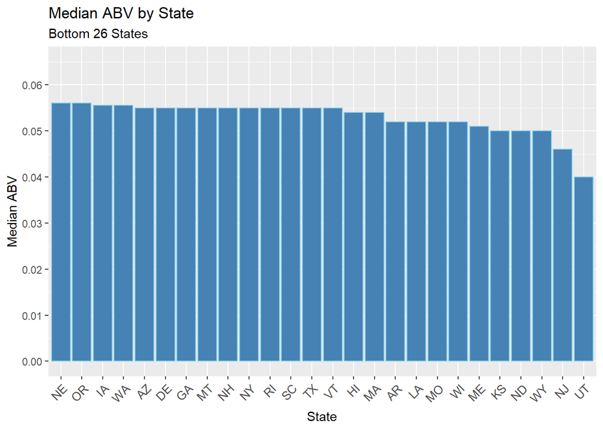

```r
tail(ABV_IBU_by_state,26) %>% ggplot(aes(x=State,y=median_ABV)) + geom_bar(stat = 'identity',color='skyblue',fill='steelblue') + xlab("State") + ylab("Median ABV") + ggtitle("Median ABV by State","Bottom 26 States") + theme(axis.text.x=element_text(size= 10, angle=45, hjust=1)) + scale_y_continuous(breaks = seq(0,0.06,0.01),limits = c(0,0.065))
```

[figure not shown]

```r
#Plot all 51 states at once
ABV_IBU_by_state %>% ggplot(aes(x=State,y=median_ABV)) + geom_bar(stat = 'identity',color='skyblue',fill='steelblue') + xlab("State") + ylab("Median ABV") + ggtitle("Median ABV by State","Top 25 States") + theme(axis.text.x=element_text(size= 7, angle=45, hjust=1)) + scale_y_continuous(breaks = seq(0,0.07,0.01),limits = c(0,0.065))
```

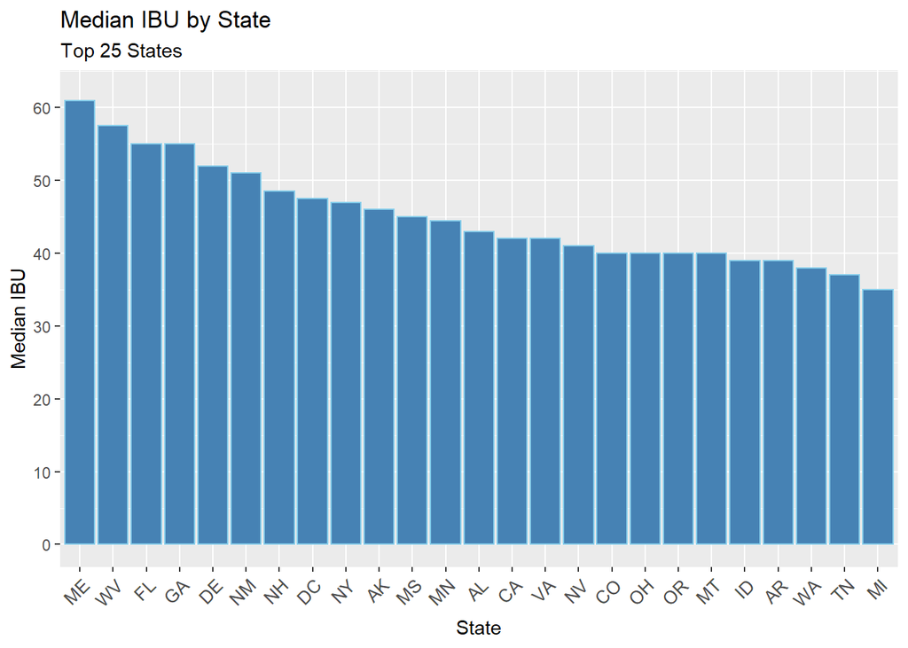

```r
##Plot Median IBU by State

#Re-order the factors for median_ABV so the bar chart can be plotted in descending order
ABV_IBU_by_state$State= fct_reorder(ABV_IBU_by_state$State, desc(ABV_IBU_by_state$median_IBU))

#Arrange the data frame where median_ABV is in descending order so that the data frame can be sliced
ABV_IBU_by_state = ABV_IBU_by_state %>% arrange(desc(median_IBU))

#For readability displaying first 25 and last 26 on the same y-scale
head(ABV_IBU_by_state,25) %>% ggplot(aes(x=State,y=median_IBU)) + geom_bar(stat = 'identity',color='skyblue',fill='steelblue') + xlab("State") + ylab("Median IBU") + ggtitle("Median IBU by State","Top 25 States") + theme(axis.text.x=element_text(size= 10, angle=45, hjust=1)) + scale_y_continuous(breaks = seq(0,65,10),limits = c(0,62))
```

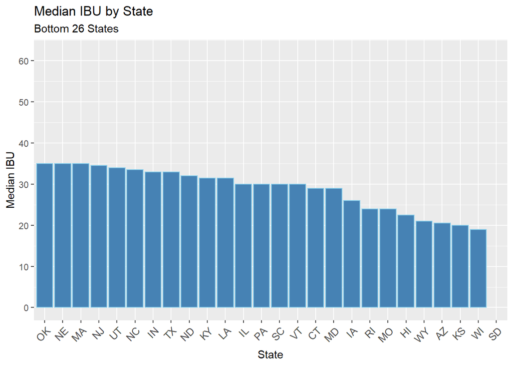

```r
tail(ABV_IBU_by_state,26) %>% ggplot(aes(x=State,y=median_IBU)) + geom_bar(stat = 'identity',color='skyblue',fill='steelblue') + xlab("State") + ylab("Median IBU") + ggtitle("Median IBU by State","Bottom 26 States") + theme(axis.text.x=element_text(size= 10, angle=45, hjust=1)) + scale_y_continuous(breaks = seq(0,65,10),limits = c(0,62))
```

[figure not shown]

```r
#Plot all 51 states at once
ABV_IBU_by_state %>% ggplot(aes(x=State,y=median_IBU)) + geom_bar(stat = 'identity',color='skyblue',fill='steelblue') + xlab("State") + ylab("Median IBU") + ggtitle("Median IBU by State","Bottom 26 States") + theme(axis.text.x=element_text(size= 7, angle=45, hjust=1)) + scale_y_continuous(breaks = seq(0,65,10),limits = c(0,62))
```

#### When looking at Median ABV by State: DC and KY are tied for the highest ABV at 6.25%, UT has the lowest median ABV by a significant margin at 4.00%, and 84% of states have a median ABV between 5% - 6% (inclusive). (Note: Only removed values are rows with NA in ABV column)

#### When looking at Median IBU by State: ME has the highest median IBU, WI has the lowest median IBU, and SD has no IBU data in the provided data sets (shown without bar in chart). (Note: Only removed values are rows with NA in IBU column)

## Find the state with the maximum alcoholic (ABV) beer and the most bitter (IBU) beer

```r
#Max ABV beer
beers_merge[which(beers_merge$ABV==max(beers_merge$ABV,na.rm = TRUE)),]
```

```
##      Brewery_id                                            Beer_Name Beer_ID
## 2048         52 Lee Hill Series Vol. 5 - Belgian Style Quadrupel Ale    2565
##        ABV IBU            Style Ounces            Brewery_Name    City State
## 2048 0.128  NA Quadrupel (Quad)   19.2 Upslope Brewing Company Boulder    CO
```

```r
#Max IBU beer
beers_merge[which(beers_merge$IBU==max(beers_merge$IBU,na.rm = TRUE)),]
```

```
##      Brewery_id                 Beer_Name Beer_ID   ABV IBU
## 1479        375 Bitter Bitch Imperial IPA     980 0.082 138
##                               Style Ounces            Brewery_Name    City
## 1479 American Double / Imperial IPA     12 Astoria Brewing Company Astoria
##      State
## 1479    OR
```

#### The highest ABV beer is Lee Hill Series Vol. 5 - Belgian Style Quadrupel Ale. The highest IBU beer is Bitter Bitch Imperial IPA.

## Analyze the summary statistics and distribution of the ABV variable.

```r
#Show the summary of the ABV Variable
summary(beers_merge$ABV)
```

```
##    Min. 1st Qu.  Median    Mean 3rd Qu.    Max.    NA's
## 0.00100 0.05000 0.05600 0.05977 0.06700 0.12800      62
```

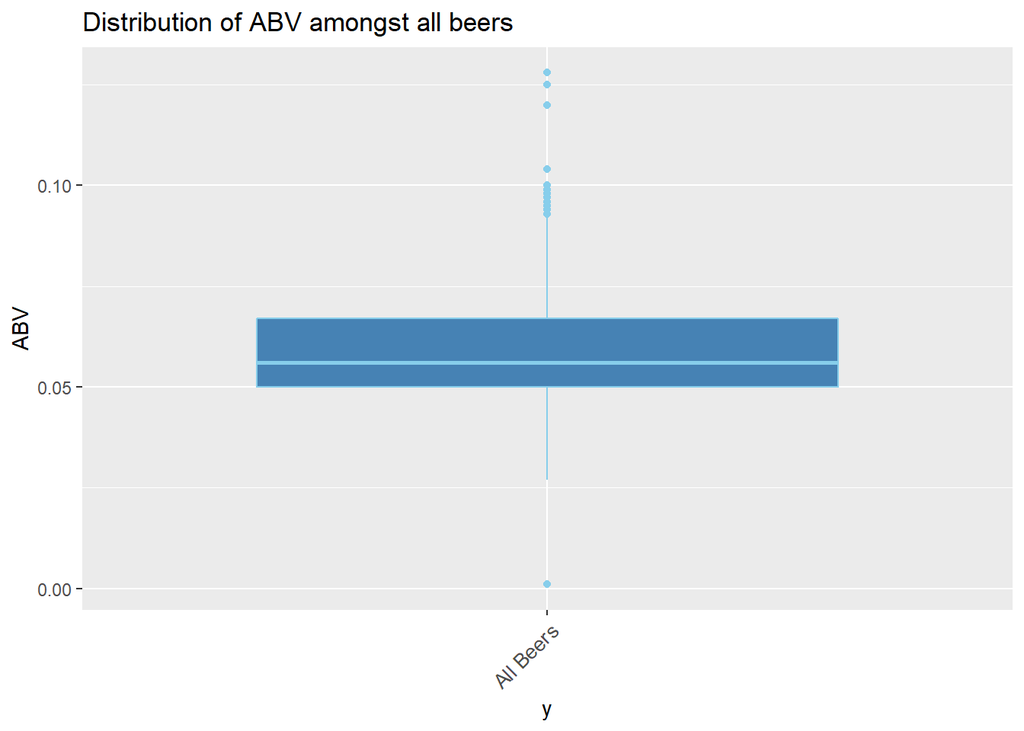

```r
#Display a box plot of ABV
beers_merge %>% ggplot() + geom_boxplot(aes(x=ABV,y="All Beers"), color='skyblue', fill='steelblue') + ggtitle("Distribution of ABV amongst all beers") + coord_flip() + theme(axis.text.x=element_text(size= 10, angle=45, hjust=1))
```

#### The distribution of ABV is slightly right skewed which signifies higher dispersion in ABV in Q3 and Q4. Median ABV amongst all analyzed beers is 5.6%. There are significantly more outliers at the higher end of ABV than the lower end. There is a small subset of ABV outliers in top quartile hovering at or just below 10% ABV. (Note: Only removed values are rows with NA in ABV column)

## Determine if there is an apparent relationship between the bitterness of the beer and its alcoholic content. Display a scatter plot.

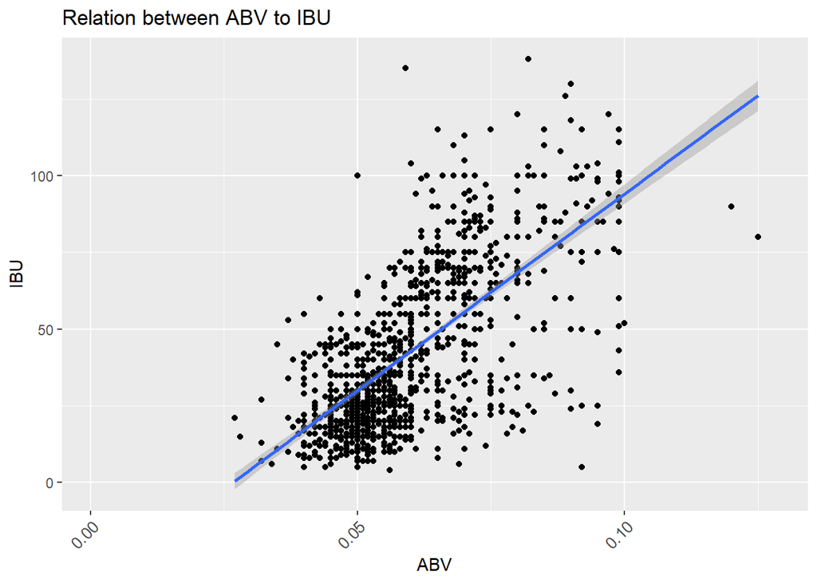

```r
#Plot scatter plot with linear trend line
beers_merge %>% ggplot(aes(x=ABV,y=IBU)) + geom_point() + geom_smooth(method = "lm") + ggtitle("Relation between ABV to IBU")+ theme(axis.text.x=element_text(size= 10, angle=45, hjust=1))
```

```r
#Display the linear model summary to evaluate the linear relationship
summary(lm(IBU~ABV,data = beers_merge))
```

```
##
## Call:
## lm(formula = IBU ~ ABV, data = beers_merge)
##
## Residuals:
##     Min      1Q  Median      3Q     Max
## -78.849 -11.977  -0.721  13.997  93.458
##
## Coefficients:
##             Estimate Std. Error t value Pr(>|t|)
## (Intercept)  -34.099      2.326  -14.66   <2e-16 ***
## ABV         1282.037     37.860   33.86   <2e-16 ***
## ---
## Signif. codes:  0 '***' 0.001 '**' 0.01 '*' 0.05 '.' 0.1 ' ' 1
##
## Residual standard error: 19.26 on 1403 degrees of freedom
##   (1005 observations deleted due to missingness)
## Multiple R-squared:  0.4497, Adjusted R-squared:  0.4493
## F-statistic:  1147 on 1 and 1403 DF,  p-value: < 2.2e-16
```

#### There is strong evidence to suggest ABV and IBU have a linear relationship (p-value < 0.0001). As ABV increases (x-axis), the IBU value (y-axis) also tends to increase showing a moderate positive linear relationship (R = 0.67). 45% of the variability in IBU can be explained by ABV (R-sqared = 0.4497).

## Compare and contrast the correlation between IBU and ABV between IPAs and other types of Ale beers using KNN classification

```r
##Before KNN, we need to clear out NAs from ABV, IBU, and Style. After diving into Style, we found 3 blanks that were not listed as NA. Blank values are not a useful prediction category. We need to clean the data set to only display complete rows with no NAs or blanks in these columns.

#Convert all blanks in beers_merge to NA
beers_merge[beers_merge==""]=NA

#Check dim of beers_merge and check how many rows without NA's
dim(beers_merge)
```

```
## [1] 2410   10
```

```r
sum(complete.cases(beers_merge))
```

```
## [1] 1403
```

```r
#Remove incomplete cases
beers_merge_clean= na.omit(beers_merge)

#Reset row names after cleaning
row.names(beers_merge_clean) = 1:dim(beers_merge_clean)[1]

#Reset factor levels of Style (because NA/blanks were removed)
beers_merge_clean$Style=factor(beers_merge_clean$Style)

#Filter dataset into beers_merge_ale to include only Ales
beers_merge_ale= beers_merge_clean[grep(x= beers_merge_clean$Style, pattern = '(\\bIPA\\b|\\bAle\\b)', ignore.case= TRUE), ]

#Create IPA_or_Other_Ale column to distinguish between IPA and non-IPA beers and divide the data between IPA and non-IPA Ale
beers_merge_ale$IPA_or_Other_Ale= beers_merge_ale$Style
beers_merge_ale$IPA_or_Other_Ale= as.character(beers_merge_ale$IPA_or_Other_Ale)
beers_merge_ale$IPA_or_Other_Ale[grepl(x= beers_merge_ale$IPA_or_Other_Ale, pattern='(\\bIPA\\b)',ignore.case=TRUE)]= "IPA"
beers_merge_ale$IPA_or_Other_Ale[grep(x= beers_merge_ale$IPA_or_Other_Ale, pattern= '(\\bAle\\b)',ignore.case=TRUE)]="Other Ale"
beers_merge_ale$IPA_or_Other_Ale=factor(beers_merge_ale$IPA_or_Other_Ale)

#Standardize values of input variables and store as new columns (Z_ABV and Z_IBU)
beers_merge_ale$Z_ABV= scale(beers_merge_ale$ABV)
beers_merge_ale$Z_IBU= scale(beers_merge_ale$IBU)

#Use KNN internal cross validation (running multiple samples due to potential ties). Input columns are Z_ABV and Z_IBU. Output column is IPA_or_Other_Ale
train_cols= beers_merge_ale[,12:13]
outcome_data= beers_merge_ale[,11]
num_rand_samples= 15
max_k= 55
accuracy_matrix= matrix(nrow= num_rand_samples, ncol=max_k)
for(i in 1:num_rand_samples)
{
  set.seed(i)

  for(j in 1:max_k)
  {
    class_data= knn.cv(train_cols,cl = outcome_data, k=j)
    CM= confusionMatrix(table(class_data,outcome_data))
    accuracy_matrix[i,j]= CM$overall[1]
  }
}
MeanAcc = colMeans(accuracy_matrix)
which(MeanAcc==max(MeanAcc))
```

```
## [1] 23
```

```r
max(MeanAcc)
```

```
## [1] 0.8685734
```

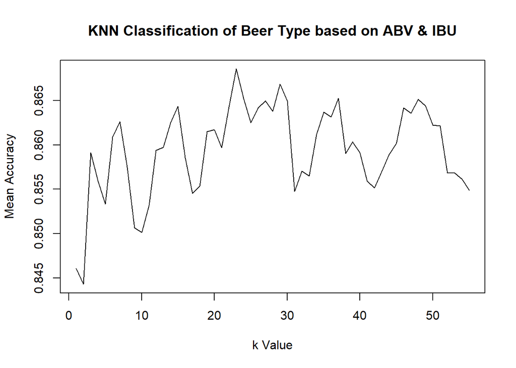

```r
plot(seq(1,max_k,1),MeanAcc, type = "l", main= "KNN Classification of Beer Type based on ABV & IBU", xlab= "k Value", ylab= "Mean Accuracy")
```

#### The KNN internal leave-one-out cross validation uses a standardized ABV and IBU to predict if the beer is an IPA or Other non-IPA Ale. All non-Ale beers were removed from the data leaving 944 beers. The KNN model was tested 15 times for every k from 1 to 55. k represents the number of closest points used to predict the category. The ideal k value for this model is 23. The mean accuracy of the model at k=23 is 86.86%. This means that 86.86% of the time the model correctly predicted the category of IPA or Other non-IPA Ale based on the ABV and IBU. This model is 1.74 times more accurate than a random classification guess which would be 50% accurate. (Note: Removed rows with NA or Blank values in ABV, IBU, or Style Variables)

## Use Naive Bayes to classify common beer styles based on ABV and IBU

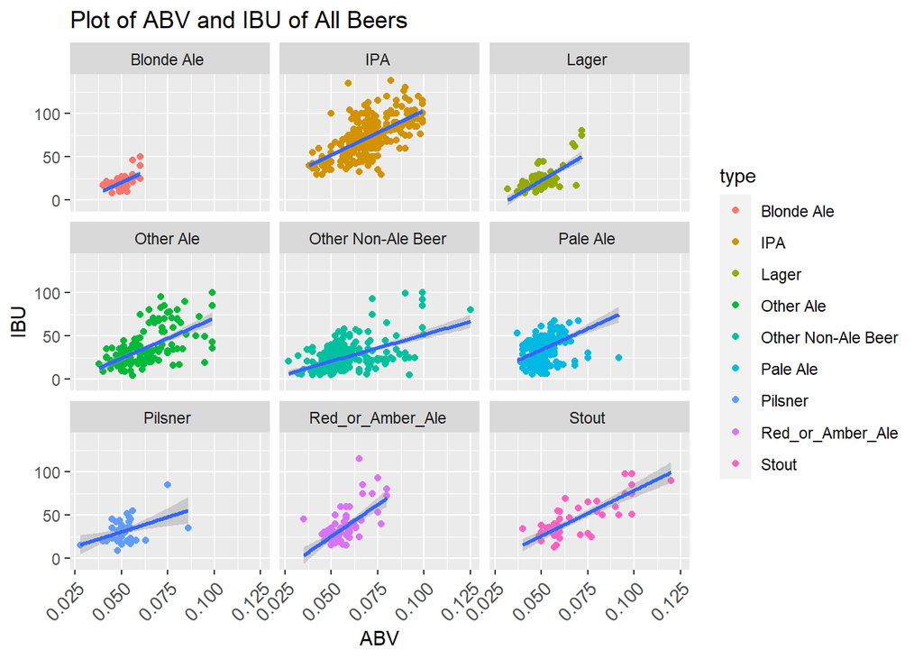

```r
##Review count of beers by style to determine generalized categories to use (uncomment code below to see the list)
#data.frame(beers_merge_clean %>% group_by(Style) %>% summarise(Count = n(), ABV_median=median(ABV), IBU_median=median(IBU)) %>% arrange(desc(Count)))

#Create beers_merge_simplified_style for Naive Bayes analysis (copy of beers_merge_clean). Create new column called 'type' which will be used to store generalized beer categories
beers_merge_simplified_style = beers_merge_clean
beers_merge_simplified_style$type = beers_merge_simplified_style$Style

#Change type column to character vector and use grep() to use keywords to create generalized beer categories
beers_merge_simplified_style$type = as.character(beers_merge_simplified_style$type)

beers_merge_simplified_style$type[grepl(x = beers_merge_simplified_style$type,pattern = '(\\bIPA\\b)',ignore.case = TRUE)]="IPA "

beers_merge_simplified_style$type[grepl(x = beers_merge_simplified_style$type,pattern = '(\\bLager\\b)',ignore.case = TRUE)]="Lager "

beers_merge_simplified_style$type[grep(x = beers_merge_simplified_style$type,pattern = '(\\bRed Ale\\b|\\bAmber Ale\\b)',ignore.case = TRUE)]="Red_or_Amber_Ale "

beers_merge_simplified_style$type[grep(x = beers_merge_simplified_style$type,pattern = '(\\bPale\\b)',ignore.case = TRUE)]="Pale Ale "

beers_merge_simplified_style$type[grep(x = beers_merge_simplified_style$type,pattern = '(\\bStout\\b)',ignore.case = TRUE)]="Stout "

beers_merge_simplified_style$type[grep(x = beers_merge_simplified_style$type,pattern = '(\\bPilsner\\b|\\bPilsener\\b)',ignore.case = TRUE)]="Pilsner "

beers_merge_simplified_style$type[grep(x = beers_merge_simplified_style$type,pattern = '(\\bBlonde\\b)',ignore.case = TRUE)]="Blonde Ale "

beers_merge_simplified_style$type[grep(x = beers_merge_simplified_style$type,pattern = '(\\bAle$)',ignore.case = TRUE)]="Other Ale "

beers_merge_simplified_style$type[grep(x = beers_merge_simplified_style$type,pattern = '(\\S)$',ignore.case = TRUE)]="Other Non-Ale Beer "

#Visualize scatter plot of type column by IBU and ABV (Use facet_wrap as well by type)
beers_merge_simplified_style  %>% ggplot(aes(x=ABV,y=IBU)) + geom_point(aes(color=type)) + geom_smooth(method = "lm") + facet_wrap(~type) + ggtitle("Plot of ABV and IBU of All Beers") + theme(axis.text.x=element_text(size= 10, angle=45, hjust=1))
```

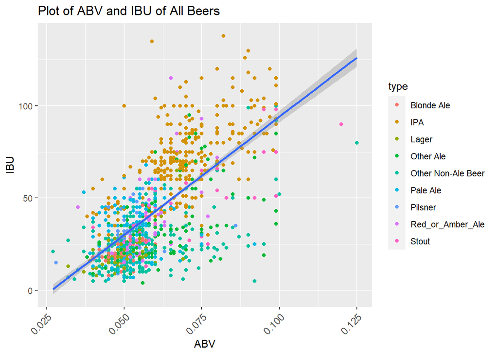

```r
beers_merge_simplified_style %>% ggplot(aes(x=ABV,y=IBU)) + geom_point(aes(color=type)) + geom_smooth(method = "lm") + ggtitle("Plot of ABV and IBU of All Beers") + theme(axis.text.x=element_text(size= 10, angle=45, hjust=1))
```

```r
## Use NB to determine probability of correct beer classification based on IBU and ABV values. Use a 70/30 split on training set vs test set. Re-run the model on 50 seeds to ensure accuracy.
beers_merge_simplified_style$type= factor(beers_merge_simplified_style$type)
iterations= 50
masterAcc=matrix(nrow= iterations)
masterSens=matrix(nrow=iterations)
masterSpec=matrix(nrow=iterations)
splitPerc= .7 #training/test split percentage
for(j in 1:iterations)
{
  set.seed(j)
  trainIndices= sample(1:dim(beers_merge_simplified_style)[1],round(splitPerc*dim(beers_merge_simplified_style)[1]))
  train= beers_merge_simplified_style[trainIndices,]
  test=beers_merge_simplified_style[-trainIndices,]

  train_columns_split_model= train[,4:5]
  test_columns= test[,4:5]

  model= naiveBayes(train_columns_split_model, train$type)
  CM= confusionMatrix(table(predict(model,test_columns), test$type))
  masterAcc[j]=CM$overall[1]
  masterSens[j]=CM$byClass[1]
  masterSpec[j]=CM$byClass[2]
}
MeanAcc=colMeans(masterAcc)
MeanSens=colMeans(masterSens)
MeanSpec= colMeans(masterSpec)
MeanAcc
```

```
## [1] 0.4499762
```

```r
MeanSens
```

```
## [1] 0.6168876
```

```r
MeanSpec
```

```
## [1] 0.8647353
```

#### The Naive Bayes model uses ABV and IBU to predict which of the 9 generalized beer types the beer falls in to (based on the generalized types manually created). The model evaluates 1403 beers which includes beers that were not evaluated in the kNN analysis and includes more specific categorization than the knn analysis. We ran the model 50 times at a 70%/30% training/test split. The mean accuracy of the 50 iterations is 45.00%. This means the model predicted the generalized type of beer 45% of the time based on the ABV and IBU. This model is 4.05 times more accurate than a random classification guess which would be 11.11% accurate. For the Naive Bayes model, the mean sensitivity is 61.69% and the mean specificity is 86.47%. (Note: Removed rows with NA or Blank values in ABV, IBU, or Style Variables)

#### Our team cleaned the data of NA values and provided clear visuals of ABV and IBU Medians at a state level. Looking deeper, our team identified a linear relationship between ABV and IBU. Leveraging this relationship, we were able to build two machine learning models to predict the style of Beer. The first used KNN to look at IPA vs Other Ales. The second used Naive Bayes to look at higher level beer types. KNN offered an accurate prediction method for this high level view of Ales. Naive Bayes offered a more granular approach while offering moderate accuracy. This analysis offers insights into the ABV and IBU ranges customers expect based on the style of beer. Also, the machine learning models can be implemented immediately while future data collection could further refine the model.